# Project 2: Data Mining, Classification, Prediction

SDS322E

# Mining, Classification, Prediction

## Morgan Daniels mcd2925

### Introduction

I chose a data set that include data on 753 families. The data is based around whether the woman of the household participates in the labor force (has a job). It includes variables counting how many children in the household are under 5, how many children are between 6 and 18, whether the wife attended college, whether the husband attended college, the log wage of the women’s earnings (adjusted if she does not have a job), and then the household income without the wife’s earnings.

This data set met the requirements for the project and intrigued me as to what results I could find about the relationship between number of children of certain age, log of wages and even college education on a woman’s choice to participate in the labor force. As an economics major I have spent a lot of course load focused on labor economics and gender and equality economics and this data set really brought together my interests. I am excited to experiment with this set for this project!

```r
library(tidyverse)
womenslfp <- read_csv("~/project2/us womens labor force.csv")

head(womenslfp)
```

```
## # A tibble: 6 x 9
##      X1 lfp      k5  k618   age wc    hc       lwg   inc
##   <dbl> <lgl> <dbl> <dbl> <dbl> <lgl> <lgl>  <dbl> <dbl>
## 1     1 TRUE      1     0    32 FALSE FALSE 1.21   10.9
## 2     2 TRUE      0     2    30 FALSE FALSE 0.329  19.5
## 3     3 TRUE      1     3    35 FALSE FALSE 1.51   12.0
## 4     4 TRUE      0     3    34 FALSE FALSE 0.0921  6.80
## 5     5 TRUE      1     2    31 TRUE  FALSE 1.52   20.1
## 6     6 TRUE      0     0    54 FALSE FALSE 1.56    9.86
```

### Cluster Analysis

```r
library(cluster)
pamdata <- womenslfp %>% select(age, lwg, inc)
pam1 <- pamdata %>% pam(k = 3)
pam1
```

```
## Medoids:
##       ID age      lwg  inc
## [1,]  68  34 1.070442 15.5
## [2,] 649  49 1.235715 15.5
## [3,] 695  43 1.122305 29.8
## Clustering vector:
##   [1] 1 1 1 1 1 2 1 2 2 1 1 2 1 2 3 1 2 1 2 1 3 1 2 2 1 3 2 1 1 2 2 2 1 2 2 2 2
##  [38] 2 2 1 1 2 1 2 1 1 2 2 2 1 3 2 1 2 2 1 2 1 2 1 3 2 2 2 1 1 2 1 3 2 1 3 2 1
##  [75] 1 2 1 2 1 3 2 2 2 2 2 2 2 2 3 1 2 1 3 3 1 2 3 1 2 3
##  [ reached getOption("max.print") -- omitted 653 entries ]
## Objective function:
##    build     swap
## 8.075540 7.378322
##
## Available components:
##  [1] "medoids"    "id.med"     "clustering" "objective"  "isolation"
##  [6] "clusinfo"   "silinfo"    "diss"       "call"       "data"
```

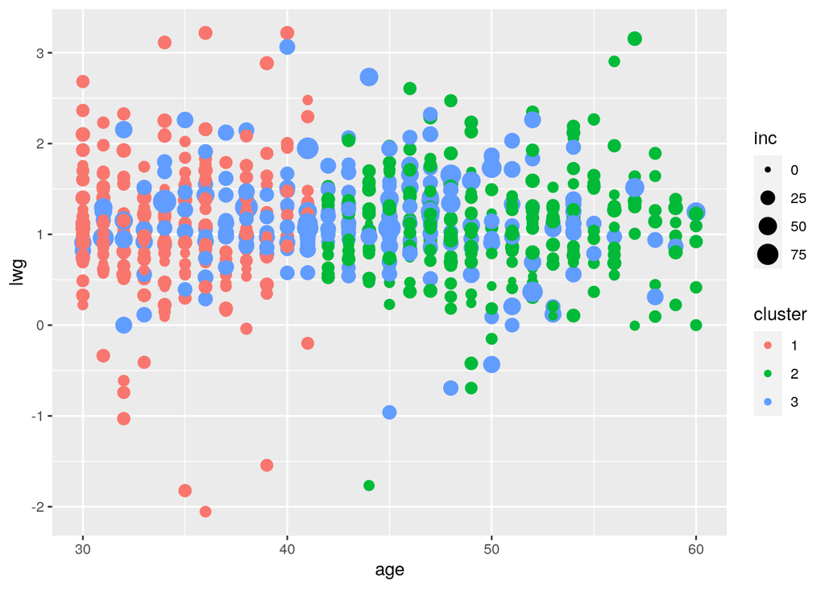

```r
pamclust <- pamdata %>% mutate(cluster = as.factor(pam1$clustering))
pamclust %>% ggplot(aes(age, lwg, color = cluster, size = inc)) +
    geom_point()
```

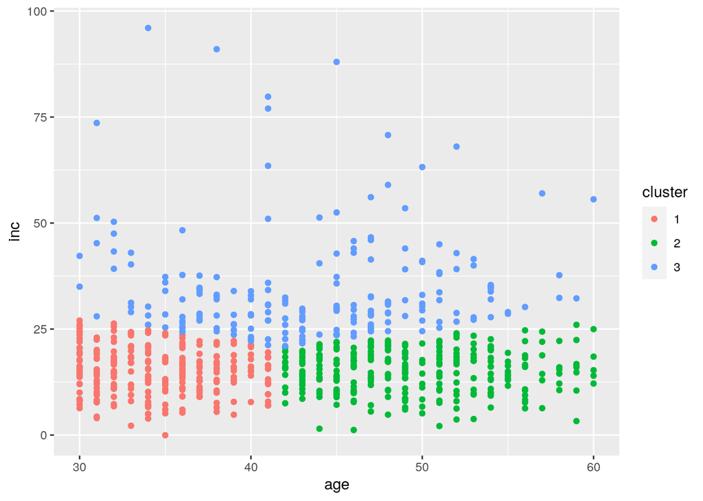

```r
pamclust %>% ggplot(aes(age, inc, color = cluster)) + geom_point()
```

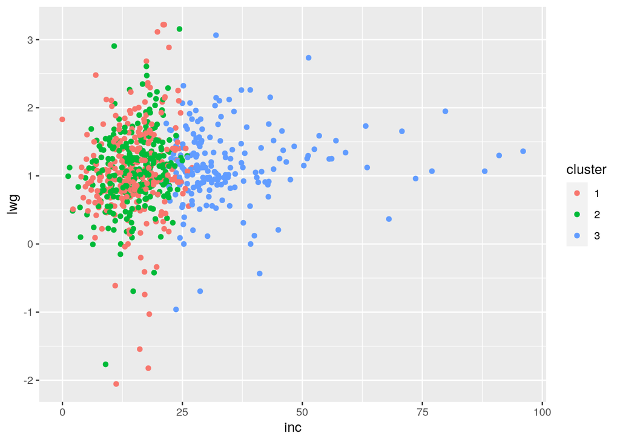

```r
pamclust %>% ggplot(aes(inc, lwg, color = cluster)) + geom_point()
```

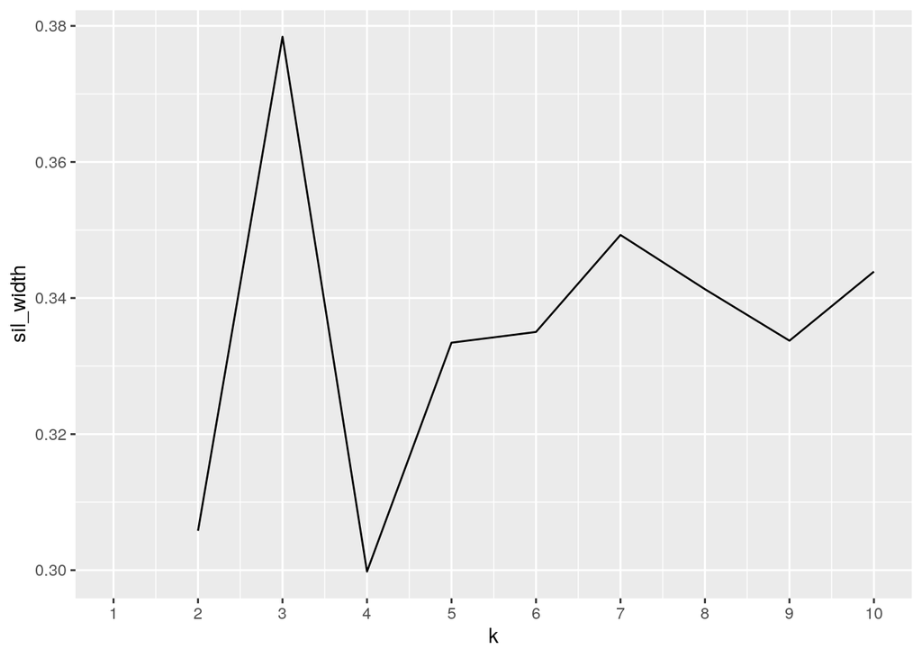

```r
sil_width <- vector()
for (i in 2:10) {
    pam_fit <- pam(pamdata, k = i)
    sil_width[i] <- pam_fit$silinfo$avg.width
}
ggplot() + geom_line(aes(x = 1:10, y = sil_width)) + scale_x_continuous(name = "k",
    breaks = 1:10)
```

I chose to cluster the age, log wage of the woman’s income, and the family income without the woman’s included because those three categories seem to related and that they could be a could fit for clustering. The goodness-of-fit test I ran showed that these variables had relatively low average silhouette width and probably create a weak structure. The graphs of the pairwise clustering show that the third cluster creates issues in all categories. The clustering has split the data into two clusters by age (approximately above 41 and below 41) and then created a third group of all high income households. These cluster do not mesh together well and show some issues with using PAM clustering on this data set.

### Dimensionality Reduction with PCA

```r
womenslfp_dat <- womenslfp %>% select_if(is.numeric) %>% scale
womenslfp_pca <- princomp(womenslfp_dat)
names(womenslfp_pca)
```

```
## [1] "sdev"     "loadings" "center"   "scale"    "n.obs"    "scores"   "call"
```

```r
summary(womenslfp_pca, loadings = T)
```

```
## Importance of components:
##                           Comp.1    Comp.2    Comp.3    Comp.4    Comp.5
## Standard deviation     1.2806444 1.0935885 1.0570971 0.9655044 0.8267062
## Proportion of Variance 0.2737052 0.1995877 0.1864900 0.1555731 0.1140586
## Cumulative Proportion  0.2737052 0.4732929 0.6597829 0.8153559 0.9294146
##                            Comp.6
## Standard deviation     0.65034610
## Proportion of Variance 0.07058541
## Cumulative Proportion  1.00000000
##
## Loadings:
##      Comp.1 Comp.2 Comp.3 Comp.4 Comp.5 Comp.6
## X1    0.132  0.731  0.278         0.567  0.203
## k5    0.545  0.207 -0.145  0.551 -0.220 -0.537
## k618  0.489 -0.156        -0.682  0.316 -0.409
## age  -0.654  0.217  0.155               -0.704
## lwg  -0.138        -0.817  0.125  0.537
## inc          0.587 -0.454 -0.452 -0.488
```

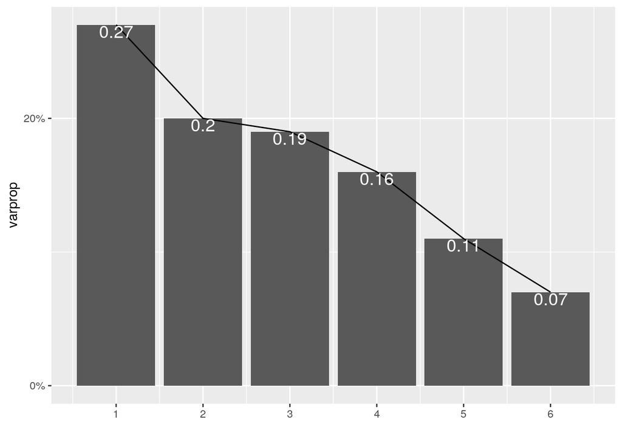

```r
eigval <- womenslfp_pca$sdev^2
varprop = round(eigval/sum(eigval), 2)

ggplot() + geom_bar(aes(y = varprop, x = 1:6), stat = "identity") +
    xlab("") + geom_path(aes(y = varprop, x = 1:6)) + geom_text(aes(x = 1:6,
    y = varprop, label = round(varprop, 2)), vjust = 1, col = "white",
    size = 5) + scale_y_continuous(breaks = seq(0, 0.6, 0.2),
    labels = scales::percent) + scale_x_continuous(breaks = 1:10)
```

```r
Name <- rownames(womenslfp)
womenslfp_pca$scores %>% as.data.frame %>% cbind(Name, .) %>%
    top_n(3, Comp.1) %>% select(Name:Comp.6)
```

```
##   Name   Comp.1   Comp.2     Comp.3     Comp.4      Comp.5    Comp.6
## 1  484 3.752815 3.899707 -2.7618291 1.10459338 -3.41648854 -1.230228
## 2  605 4.094923 1.189066 -0.1041668 2.42685086 -0.02359848 -2.682693
## 3  746 4.097867 0.685904  0.7693191 0.08617553  1.71647849 -2.669378
```

```r
womenslfp_pca$scores %>% as.data.frame %>% cbind(Name, .) %>%
    top_n(3, wt = desc(Comp.1)) %>% select(Name:Comp.6)
```

```
##   Name    Comp.1     Comp.2     Comp.3    Comp.4      Comp.5     Comp.6
## 1   27 -2.361250 -0.9160671 -0.3675517 0.4065668 -0.58173930 -1.1486817
## 2   73 -2.311054 -1.0194091 -0.5333468 0.6370287 -0.07393227 -1.0644489
## 3  141 -2.329890 -0.6325819 -0.9446659 0.5694342  0.17055188 -0.9927076
```

```r
womenslfp_pca$scores %>% as.data.frame %>% cbind(Name, .) %>%
    top_n(3, wt = Comp.2) %>% select(Name:Comp.6)
```

```
##   Name       Comp.1   Comp.2    Comp.3    Comp.4    Comp.5     Comp.6
## 1  484  3.752814913 3.899707 -2.761829  1.104593 -3.416489 -1.2302281
## 2  647  1.799095975 4.692882 -3.327329 -2.251222 -2.463378  0.5248368
## 3  729 -0.009461411 4.507581 -2.014054 -3.095444 -1.683018  0.6325992
```

```r
womenslfp_pca$scores %>% as.data.frame %>% cbind(Name, .) %>%
    top_n(3, wt = desc(Comp.2)) %>% select(Name:Comp.6)
```

```
##   Name    Comp.1    Comp.2    Comp.3     Comp.4     Comp.5     Comp.6
## 1    4 1.0691115 -2.300075  1.416621 -0.8947869 -0.8982191  0.1104364
## 2   20 0.9137951 -2.437929 -1.320057 -1.1384086  1.0070211 -0.3907716
## 3   65 0.3489127 -2.360082 -1.652973 -0.9340116  1.7258043 -0.9290422
```

```r
womenslfp_pca$scores %>% as.data.frame %>% cbind(Name, .) %>%
    top_n(3, wt = Comp.3) %>% select(Name:Comp.6)
```

```
##   Name   Comp.1     Comp.2   Comp.3     Comp.4    Comp.5      Comp.6
## 1  126 1.137722 -0.9102485 3.777826 -1.1706336 -3.027925  0.66689703
## 2  220 2.209976 -0.4778700 4.223319  0.1247961 -3.126359 -0.38602929
## 3  348 0.533757 -0.3798651 4.503593 -0.7811092 -1.960076  0.02344862
```

```r
womenslfp_pca$scores %>% as.data.frame %>% cbind(Name, .) %>%
    top_n(3, wt = desc(Comp.3)) %>% select(Name:Comp.6)
```

```
##   Name     Comp.1   Comp.2    Comp.3     Comp.4     Comp.5     Comp.6
## 1  119  1.5414291 2.665156 -3.599351 -2.8398002 -3.4187818 -0.6568860
## 2  369 -0.8967898 1.299223 -3.423800 -0.9457409  0.1924135  0.3140156
## 3  386 -0.8396195 2.945175 -3.523326 -1.6752701 -1.9375845  1.1586145
```

```r
womenslfp_pca$scores %>% as.data.frame %>% cbind(Name, .) %>%
    top_n(3, wt = Comp.4) %>% select(Name:Comp.6)
```

```
##   Name   Comp.1     Comp.2      Comp.3   Comp.4      Comp.5      Comp.6
## 1  111 1.838079 -0.8069388 -2.45826035 2.987562 -0.55862365 -0.75286988
## 2  450 2.249025  0.4768138 -1.38099481 2.952712 -0.24606245 -0.29666325
## 3  732 2.576069  1.3135444  0.05028457 3.091288  0.05956474 -0.01299289
```

```r
womenslfp_pca$scores %>% as.data.frame %>% cbind(Name, .) %>%
    top_n(3, wt = desc(Comp.4)) %>% select(Name:Comp.6)
```

```
##   Name    Comp.1     Comp.2      Comp.3    Comp.4     Comp.5     Comp.6
## 1   53 2.6901974 -2.1802841  1.29439844 -3.830522  0.1172923 -1.5947861
## 2  327 0.3956349  0.7680725  0.02095641 -3.192435 -0.4132385 -1.5696072
## 3  728 0.6882938  3.7228163 -1.61947788 -3.156697 -1.0123937  0.5934003
```

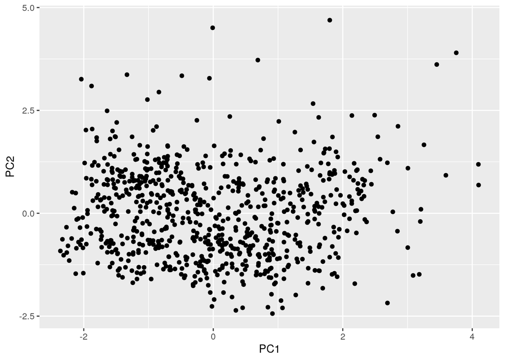

```r
womenslfpdf <- data.frame(Name = womenslfp, PC1 = womenslfp_pca$scores[,
    1], PC2 = womenslfp_pca$scores[, 2])
ggplot(womenslfpdf, aes(PC1, PC2)) + geom_point()
```

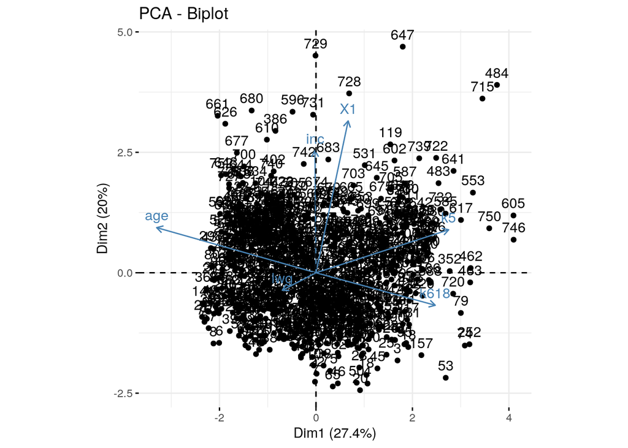

```r
library(factoextra)
fviz_pca_biplot(womenslfp_pca) + coord_fixed()
```

### Linear Classifier

```r
fit <- glm(lfp ~ k5 + k618 + age + lwg + inc, data = womenslfp,
    family = "binomial")

score <- predict(fit, type = "response")

class_diag(score, womenslfp$lfp, positive = 1)
```

```
##            acc   sens spec    ppv     f1     ba    auc
## Metrics 0.6627 0.8014 0.48 0.6699 0.7298 0.6407 0.7307
```

```r
k = 10
data <- womenslfp[sample(nrow(womenslfp)), ]
folds <- cut(seq(1:nrow(womenslfp)), breaks = k, labels = F)
diags <- NULL
for (i in 1:k) {
    train <- data[folds != i, ]
    test <- data[folds == i, ]
    truth <- test$lfp
    fit <- glm(lfp ~ k5 + k618 + age + lwg + inc, data = train,
        family = "binomial")
    probs <- predict(fit, newdata = test, type = "response")
    diags <- rbind(diags, class_diag(probs, truth, positive = 1))
}
summarize_all(diags, mean)
```

```
##       acc    sens    spec     ppv      f1      ba     auc
## 1 0.65616 0.79208 0.46756 0.66498 0.72164 0.62983 0.72259
```

I chose a logistic regression to predict a woman’s labor force participation based on the number of children she has under 5, the number of children she has between 6 and 18, the log of her wage if she works, and the household income without the woman’s.

### Non-Parametric Classifier

```r
library(caret)
knn_fit <- knn3(factor(lfp == 1, levels = c("TRUE", "FALSE")) ~
    k5 + k618 + age + lwg + inc, data = womenslfp, k = 5)
y_hat_knn <- predict(knn_fit, womenslfp)
head(y_hat_knn)
```

```
##      TRUE FALSE
## [1,]  0.6   0.4
## [2,]  0.6   0.4
## [3,]  0.8   0.2
## [4,]  0.4   0.6
## [5,]  0.6   0.4
## [6,]  0.6   0.4
```

```r
table(truth = factor(womenslfp$lfp == 1, levels = c("TRUE", "FALSE")),
    prediction = factor(y_hat_knn[, 1] > 0.5, levels = c("TRUE",
        "FALSE")))
```

```
##        prediction
## truth   TRUE FALSE
##   TRUE   329    99
##   FALSE  106   219
```

```r
class_diag(y_hat_knn[, 1], womenslfp$lfp, positive = 1)
```

```
##            acc   sens   spec    ppv     f1     ba    auc
## Metrics 0.7278 0.7687 0.6738 0.7563 0.7625 0.7213 0.7822
```

```r
k = 10
data <- womenslfp[sample(nrow(womenslfp)), ]
folds <- cut(seq(1:nrow(womenslfp)), breaks = k, labels = F)
diags <- NULL
for (i in 1:k) {
    train <- data[folds != i, ]
    test <- data[folds == i, ]
    truth <- test$lfp
    fit <- knn3(lfp ~ k5 + k618 + age + lwg + inc, data = train)
    probs <- predict(fit, newdata = test)[, 2]
    diags <- rbind(diags, class_diag(probs, truth, positive = 1))
}
summarize_all(diags, mean)
```

```
##       acc    sens    spec     ppv      f1     ba     auc
## 1 0.56711 0.65738 0.45362 0.61105 0.63048 0.5555 0.56258
```

This k-nearest-neighbors predictor creates a similar AUC to the linear prediction before about 0.7822. This is the highet result I’ve seen meaning this is likely a good predictor for a woman’s labor force participation based on the number of children then have in different age ranges, log of their wage if they work, and the household income without the woman’s income included. When performing a k-fold CV the AUC becomes way lower meaning this may not be a great fit.

### Regression/Numeric Prediction

```r
fit <- lm(lwg ~ ., data = womenslfp)
yhat <- predict(fit)

mean((womenslfp$lwg - yhat)^2)
```

```
## [1] 0.3002423
```

```r
k = 5
data <- womenslfp[sample(nrow(womenslfp)), ]
folds <- cut(seq(1:nrow(womenslfp)), breaks = k, labels = F)
diags <- NULL
for (i in 1:k) {
    train <- data[folds != i, ]
    test <- data[folds == i, ]
    fit <- lm(lwg ~ ., data = train)
    yhat <- predict(fit, newdata = test)
    diags <- mean((test$lwg - yhat)^2)
}
mean(diags)
```

```
## [1] 0.2314822
```

### Python

```r
library(reticulate)

k5 <- "children under the age of 5"
```

```python
k618="and children between 6 and 18"

print(r.k5,k618)
```

```
## children under the age of 5 and children between 6 and 18
```

### Concluding Remarks

The women’s labor force participation data set was much more interesting and fun to play with than my first project set. I enjoyed seeing the regression and predictions on the variables and the practical uses of the R functions we learned in the second half of the semester.